```python
import time

import tensorflow as tf

from tensorflow.keras import datasets, layers, models
import matplotlib.pyplot as plt
from keras.layers.normalization import BatchNormalization
from tensorflow.keras.preprocessing.image import ImageDataGenerator

from matplotlib import pyplot
from keras.datasets import cifar10
from keras.utils import to_categorical
from keras.models import Sequential
from keras.layers import Conv2D
from keras.layers import MaxPooling2D
from keras.layers import Dense
from keras.layers import Flatten
from keras.layers import Dropout
from keras import regularizers
from keras.optimizers import SGD
from keras.utils.vis_utils import model_to_dot
```

# Importeren van de data

```python
(X_train, y_train), (X_test, y_test) = datasets.cifar10.load_data()

# normaliseren van de data
X_train, X_test = X_train / 255.0, X_test / 255.0
```

# Data checken

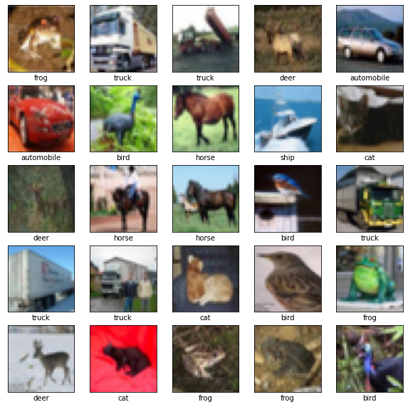

```python
class_names = ['airplane', 'automobile', 'bird', 'cat', 'deer',
               'dog', 'frog', 'horse', 'ship', 'truck']

plt.figure(figsize=(10,10))
for i in range(25):
    plt.subplot(5,5,i+1)
    plt.xticks([])
    plt.yticks([])
    plt.grid(False)
    plt.imshow(X_train[i], cmap=plt.cm.binary)
    # The CIFAR labels happen to be arrays,
    # which is why you need the extra index
    plt.xlabel(class_names[y_train[i][0]])
plt.show()
```

# Prep data

```python
y_train = to_categorical(y_train)
y_test = to_categorical(y_test)
```

# Modelling

## Baseline

```python
model = Sequential()
```

```python
# Convolution Layer 1
model.add(Conv2D(32, (3, 3), activation='relu', input_shape=(32, 32, 3)))

# Convolution Layer 2
model.add(Conv2D(32, (3, 3), activation='relu'))
model.add(MaxPooling2D((2, 2)))
```

```python
model.add(Flatten()) # flatten toevoegen zodat we er een fully connected netwerk op kunnen aansluiten
```

```python
# Fully Connected Layer 3
model.add(Dense(64, activation='relu'))

# Fully Connected Layer 4 (outputlayer)
model.add(Dense(10, activation='softmax'))
```

```python
model.compile(loss='categorical_crossentropy', optimizer='adam', metrics=['accuracy'])
```

```python
startTime = time.time()
history = model.fit(X_train, y_train, batch_size = 64, epochs=15, verbose=1, validation_split = 0.2)
print("Time: ", time.time() - startTime)
```

```
Time:  551.3827819824219
```

```python
model.summary()
```

```
Model: "sequential"
_________________________________________________________________
Layer (type)                 Output Shape              Param #
=================================================================
conv2d (Conv2D)              (None, 30, 30, 32)        896
_________________________________________________________________
conv2d_1 (Conv2D)            (None, 28, 28, 32)        9248
_________________________________________________________________
max_pooling2d (MaxPooling2D) (None, 14, 14, 32)        0
_________________________________________________________________
flatten (Flatten)            (None, 6272)              0
_________________________________________________________________
dense (Dense)                (None, 64)                401472
_________________________________________________________________
dense_1 (Dense)              (None, 10)                650
=================================================================
Total params: 412,266
Trainable params: 412,266
Non-trainable params: 0
_________________________________________________________________
```

```python
accuracy_high_score =  max(history.history['val_accuracy'])
accuracy_high_score
```

```
0.6678000092506409
```

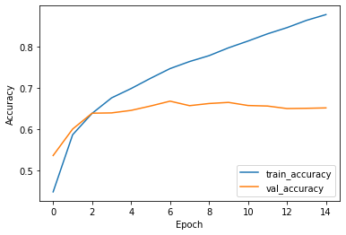

```python
plt.plot(history.history['accuracy'], label='train_accuracy')
plt.plot(history.history['val_accuracy'], label = 'val_accuracy')
plt.xlabel('Epoch')
plt.ylabel('Accuracy')
plt.legend(loc='lower right')
```

Hier is heel mooi te zien dat er spraken is van overfitting. Dit is namelijk te zien dat de trian accuracy nog duidelijk toe neemt. Terwijl de validation accuracy al een tijdje niet meer toe neemt. Ik zou zeggen na epoch 6 is die overfitted

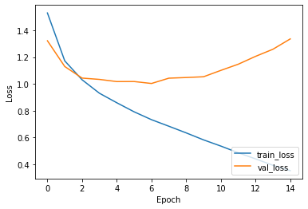

```python
plt.plot(history.history['loss'], label='train_loss')
plt.plot(history.history['val_loss'], label = 'val_loss')
plt.xlabel('Epoch')
plt.ylabel('Loss')
plt.legend(loc='lower right')
```

Ook is het duidelijk te zien aan de loss dat er spraken is van overfitting na epoch 6 (en misschien zelfs al iets eerder). De loss op de training set daalt nog aardig, terwijl de validation loss na epoch 6 zelfs toe neemt.

## Meer convolutional layers

```python
model = Sequential()
```

```python
# Convolution Layer 1
model.add(Conv2D(32, (3, 3), activation='relu', input_shape=(32, 32, 3)))

# Convolution Layer 2
model.add(Conv2D(32, (3, 3), activation='relu'))
model.add(MaxPooling2D((2, 2)))

# # Convolution Layer 3
model.add(Conv2D(64, (3, 3), activation='relu'))

# # Convolution Layer 4
model.add(Conv2D(64, (3, 3), activation='relu'))
model.add(MaxPooling2D((2, 2)))
```

```python
model.add(Flatten()) # flatten toevoegen zodat we er een fully connected netwerk op kunnen aansluiten
```

```python
# Fully Connected Layer 5
model.add(Dense(64, activation='relu'))

# Fully Connected Layer 6 (outputlayer)
model.add(Dense(10, activation='softmax'))
```

```python
model.compile(loss='categorical_crossentropy', optimizer='adam', metrics=['accuracy'])
```

```python
startTime = time.time()
history = model.fit(X_train, y_train, batch_size = 64, epochs=15, verbose=1, validation_split = 0.2)
print("Time: ", time.time() - startTime)
```

```
Time:  781.7718694210052
```

```python
print("Minder conv layers score:", accuracy_high_score, "\nMeer conv layers score", max(history.history['val_accuracy']))
```

```
Minder conv layers score: 0.6678000092506409
Meer conv layers score 0.7360000014305115
```

Het toevoegen van convolutional layers heeft een mooie verbetering geleverd.

```python
if history.history['val_accuracy'][-1] > accuracy_high_score:
    accuracy_high_score = max(history.history['val_accuracy'])
```

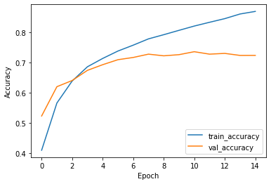

```python
plt.plot(history.history['accuracy'], label='train_accuracy')
plt.plot(history.history['val_accuracy'], label = 'val_accuracy')
plt.xlabel('Epoch')
plt.ylabel('Accuracy')
plt.legend(loc='lower right')
```

Hier is duidelijk te zien dat er ongeveer vanaf epoch 7 weer spraken is van overfitten. De train accuracy blijft nog wel toe nemen terwijl de validation accuracy het zelfde blijft.

## Het toevoegen van extra fully connected layers

```python
model = Sequential()
```

```python
# Convolution Layer 1
model.add(Conv2D(32, (3, 3), activation='relu', input_shape=(32, 32, 3)))

# Convolution Layer 2
model.add(Conv2D(32, (3, 3), activation='relu'))
model.add(MaxPooling2D((2, 2)))

# # Convolution Layer 3
model.add(Conv2D(64, (3, 3), activation='relu'))

# # Convolution Layer 4
model.add(Conv2D(64, (3, 3), activation='relu'))
model.add(MaxPooling2D((2, 2)))
```

```python
model.add(Flatten()) # flatten toevoegen zodat we er een fully connected netwerk op kunnen aansluiten
```

```python
# Fully Connected Layer 5
model.add(Dense(128, activation='relu'))

# Fully Connected Layer 6
model.add(Dense(64, activation='relu'))

# Fully Connected Layer 7
model.add(Dense(32, activation='relu'))

# Fully Connected Layer 8 (outputlayer)
model.add(Dense(10, activation='softmax'))
```

```python
model.compile(loss='categorical_crossentropy', optimizer='adam', metrics=['accuracy'])
```

```python
startTime = time.time()
history = model.fit(X_train, y_train, batch_size = 64, epochs=15, verbose=1, validation_split = 0.2)
print("Time: ", time.time() - startTime)
```

```
Time:  793.4219107627869
```

Het trainen van 15 epochs begint wel lang te duren: 800 seconden. Dit komt door een combinatie van pc performance en model complexiteit. Hoe complexer het model hoe langer het duurt om een epoch te trainen. Maar het grootste probleem is de pc performance. Ik kan het namelijk niet trainen met mijn GPU waardoor het ongeveer 40 keer zo snel had kunnen gaan.

```python
print("Vorige score:", accuracy_high_score, "\nMeer fully connected layers score", max(history.history['val_accuracy']))
```

```
Vorige score: 0.7360000014305115
Meer fully connected layers score 0.736299991607666
```

Dit geeft maar een hele minimale verbetering. Nu is het de vraag of we dit wel willen houden. De complexiteit van het model wordt meer maar de resultaten niet, met overfitting als mogelijk resultaat. Toch laat ik het in mijn model zitten, omdat ik denk dat het een nuttige bijdrage kan leveren als we aanvullende technieken er bij toevoegen zoals bijvoorbeeld: data augmentation, Weight decay en batch normalisatie. Ik zou dit graag willen testen of de extra fully connected layers met behulp van de aanvullende technieken een verbetering opleveren. Maar door de tijd die het kost om het netwerk te trainen is dit niet mogelijk. **Pc performance :(**

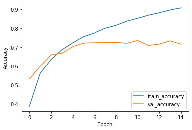

```python
plt.plot(history.history['accuracy'], label='train_accuracy')
plt.plot(history.history['val_accuracy'], label = 'val_accuracy')
plt.xlabel('Epoch')
plt.ylabel('Accuracy')
plt.legend(loc='lower right')
```

Hier is ook weer duidelijk een geval van overfitting te zien. De train accuracy wordt weer meer en de validation accuracy neemt niet meer toe. Dit is ongeveer weer het geval bij epoch 6.

## Toevoegen van nog een extra layers en padding in de convolutionele layers

We gaan ondanks dat het toenemen van de complexiteit van het model met als resultaat hele langen trainings tijden. Het toch proberen of het verhogen van de complexiteit een beter resultaat zal geven op de validation set

```python
model = Sequential()
```

padding='same' veroorzaakt padding van 1, wat hopelijk een positief resultaat geeft

```python
# Convolution Layer 1
model.add(Conv2D(32, (3, 3), activation='relu', input_shape=(32, 32, 3), padding='same'))

# Convolution Layer 2
model.add(Conv2D(32, (3,3), padding='same', activation='relu'))
model.add(MaxPooling2D(pool_size=(2,2)))

# Convolution Layer 3
model.add(Conv2D(64, (3,3), padding='same', activation='relu'))

# Convolution Layer 4
model.add(Conv2D(64, (3,3), padding='same', activation='relu'))
model.add(MaxPooling2D(pool_size=(2,2)))

# Convolution Layer 5
model.add(Conv2D(128, (3,3), padding='same', activation='relu'))

# Convolution Layer 6
model.add(Conv2D(128, (3,3), padding='same', activation='relu'))
model.add(MaxPooling2D(pool_size=(2,2)))
```

```python
model.add(Flatten()) # flatten toevoegen zodat we er een fully connected netwerk op kunnen aansluiten
```

```python
# Fully Connected Layer 7
model.add(Dense(128, activation='relu'))

# Fully Connected Layer 8
model.add(Dense(64, activation='relu'))

# Fully Connected Layer 9
model.add(Dense(32, activation='relu'))

# Fully Connected Layer 10 (outputlayer)
model.add(Dense(10, activation='softmax'))
```

```python
model.compile(loss='categorical_crossentropy', optimizer='adam', metrics=['accuracy'])
```

```python
startTime = time.time()
history = model.fit(X_train, y_train, batch_size = 64, epochs=15, verbose=1, validation_split = 0.2)
print("Time: ", time.time() - startTime)
```

```
Time:  1515.9519069194794
```

```python
print("Vorige score:", accuracy_high_score, "\nMeer convolutionele layers en padding score", max(history.history['val_accuracy']))
```

[output not shown]

Dit geeft toch een beter resultaat op de validation accuracy. Maar of het nou komt door het toevoegen van extra layers of door de padding is hier niet uit op te maken. Nogmaals dit zou ik willen testen maar dit model trainen met 15 epochs duurde al 1515 seconden.....

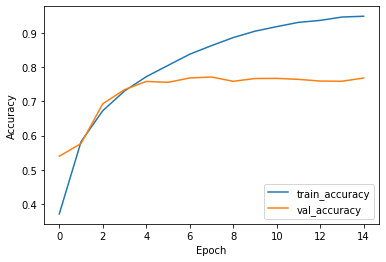

```python
plt.plot(history.history['accuracy'], label='train_accuracy')
plt.plot(history.history['val_accuracy'], label = 'val_accuracy')
plt.xlabel('Epoch')
plt.ylabel('Accuracy')
plt.legend(loc='lower right')
```

Ook hier is weer na epoch 6 een duidelijk geval van overfitting

## Toevoegen van batch normalization

Batch normalization zou de resultaten op de validation set moeten verbeteren en nog belangrijker in mijn geval: de train snelheid.

```python
model = Sequential()
```

```python
# Convolution Layer 1
model.add(Conv2D(32, (3, 3), activation='relu', input_shape=(32, 32, 3), padding='same'))
model.add(BatchNormalization())

# Convolution Layer 2
model.add(Conv2D(32, (3,3), padding='same', activation='relu'))
model.add(BatchNormalization())
model.add(MaxPooling2D(pool_size=(2,2)))

# Convolution Layer 3
model.add(Conv2D(64, (3,3), padding='same', activation='relu'))
model.add(BatchNormalization())

# Convolution Layer 4
model.add(Conv2D(64, (3,3), padding='same', activation='relu'))
model.add(BatchNormalization())
model.add(MaxPooling2D(pool_size=(2,2)))

# Convolution Layer 5
model.add(Conv2D(128, (3,3), padding='same', activation='relu'))
model.add(BatchNormalization())

# Convolution Layer 6
model.add(Conv2D(128, (3,3), padding='same', activation='relu'))
model.add(BatchNormalization())
model.add(MaxPooling2D(pool_size=(2,2)))
```

```python
model.add(Flatten()) # flatten toevoegen zodat we er een fully connected netwerk op kunnen aansluiten
```

```python
# Fully Connected Layer 7
model.add(Dense(128, activation='relu'))
model.add(BatchNormalization())

# Fully Connected Layer 8
model.add(Dense(64, activation='relu'))
model.add(BatchNormalization())

# Fully Connected Layer 9
model.add(Dense(32, activation='relu'))
model.add(BatchNormalization())

# Fully Connected Layer 10 (outputlayer)
model.add(Dense(10, activation='softmax'))
```

```python
model.compile(loss='categorical_crossentropy', optimizer='adam', metrics=['accuracy'])
```

```python
startTime = time.time()
history = model.fit(X_train, y_train, batch_size = 64, epochs=15, verbose=1, validation_split = 0.2)
print("Time: ", time.time() - startTime)
```

```
Time:  2414.250972509384
```

De tijd is er jammer genoeg niet door verminderd. Het is zelfs heel erg veel gestegen, van 1515 naar 2414 seconden

```python
print("Toevoegen van batch normalization score: ", max(history.history['val_accuracy']))
```

```
Toevoegen van batch normalization score:  0.7918999791145325
```

Wel is gelukkig de resultaten op de validation set toegenomen: met 0.02. Dit is niet veel maar omdat het resultaat al rond de 0.8 ligt wordt het steeds lastiger om de score te verhogen. Daarom is in dit gevaal 0.02 een goede verbetering

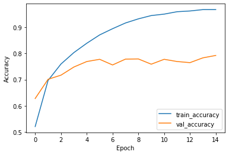

```python
plt.plot(history.history['accuracy'], label='train_accuracy')
plt.plot(history.history['val_accuracy'], label = 'val_accuracy')
plt.xlabel('Epoch')
plt.ylabel('Accuracy')
plt.legend(loc='lower right')
```

Ook hier is weer een duidelijk geval van overfitting rond epoch 5

## Toevoegen van dropout

De functionaliteit van de dropout zou er voor moeten zorgen dat het model robuster wordt en dus een beter resultaat geeft op de validation set. De dropout zet tijdens de epochs sommige neuronen uit waardoor de omliggende neuronen het moeten oppakken. Waardoor de neuronen minder afhankelijk van elkaar worden.

```python
model = Sequential()
```

Ik voeg om de layer dropout toe. Dit doe ik omdat ik anders bang ben dat het te veel wordt. Ik zou het ook graag op alle layers willen testen of dit idnderdaad te veel wordt maar het fitten duurt super lang :(

```python
# Convolution Layer 1
model.add(Conv2D(32, (3, 3), activation='relu', input_shape=(32, 32, 3), padding='same'))
model.add(BatchNormalization())

# Convolution Layer 2
model.add(Conv2D(32, (3,3), padding='same', activation='relu'))
model.add(BatchNormalization())
model.add(MaxPooling2D(pool_size=(2,2)))
model.add(Dropout(0.2))

# Convolution Layer 3
model.add(Conv2D(64, (3,3), padding='same', activation='relu'))
model.add(BatchNormalization())

# Convolution Layer 4
model.add(Conv2D(64, (3,3), padding='same', activation='relu'))
model.add(BatchNormalization())
model.add(MaxPooling2D(pool_size=(2,2)))
model.add(Dropout(0.2))

# Convolution Layer 5
model.add(Conv2D(128, (3,3), padding='same', activation='relu'))
model.add(BatchNormalization())

# Convolution Layer 6
model.add(Conv2D(128, (3,3), padding='same', activation='relu'))
model.add(BatchNormalization())
model.add(MaxPooling2D(pool_size=(2,2)))
model.add(Dropout(0.2))
```

```python
model.add(Flatten()) # flatten toevoegen zodat we er een fully connected netwerk op kunnen aansluiten
```

```python
# Fully Connected Layer 7
model.add(Dense(128, activation='relu'))
model.add(BatchNormalization())

# Fully Connected Layer 8
model.add(Dense(64, activation='relu'))
model.add(BatchNormalization())

# Fully Connected Layer 9
model.add(Dense(32, activation='relu'))
model.add(BatchNormalization())

# Fully Connected Layer 10 (outputlayer)
model.add(Dense(10, activation='softmax'))
```

```python
model.compile(loss='categorical_crossentropy', optimizer='adam', metrics=['accuracy'])
```

```python
startTime = time.time()
history = model.fit(X_train, y_train, batch_size = 64, epochs=15, verbose=1, validation_split = 0.2)
print("Time: ", time.time() - startTime)
```

```
Time:  2672.8374276161194
```

Het trainen heeft weer super lang geduurt. 15 epochs doen er 2672 seconden over om te trainen.

```python
print("Toevoegen van dropout score: ", max(history.history['val_accuracy']))
```

```
Toevoegen van dropout score: 0.8227999806404114
```

Dit is mooi, er is weer een kleiner verbetering van 0.03.

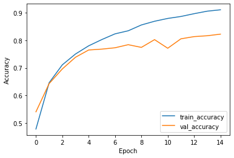

```python
plt.plot(history.history['accuracy'], label='train_accuracy')
plt.plot(history.history['val_accuracy'], label = 'val_accuracy')
plt.xlabel('Epoch')
plt.ylabel('Accuracy')
plt.legend(loc='lower right')
```

Het mooiste aan de dropout is dit. Er is duidelijk te zien dat het overfitten pas later gebeurt. De validation accuracy neemt zelfs nog toe na 15 epochs. Het kan zijn dat met het draaien van meer epochs er een nog hoger resultaat uit komt.

## Layer weight regularizer toevoegen

De layer weight regularizer zou het zelfde effect moeten geven als de dropout: het model robuster maken. Met als resultaat een hogere accuracy op de validation set

Bron: https://keras.io/api/layers/regularizers/ Hier gebruiken ze voor de l2 regularizer 0.0001. Ik zou graag verschillende dingen hiermee proberen maar dit duurt echt veelste lang met trainen dus ik ga alleen kijken of de default effect heeft. Ik heb alleen voor l2 regularizer gekozen omdat ik die het vaakste terug zie komen, in lesvoorbeelden en op het internet.

```python
model = Sequential()
```

```python
# Convolution Layer 1
model.add(Conv2D(32, (3, 3), activation='relu', input_shape=(32, 32, 3), padding='same', kernel_regularizer=regularizers.l2(0.0001)))
model.add(BatchNormalization())

# Convolution Layer 2
model.add(Conv2D(32, (3,3), padding='same', activation='relu', kernel_regularizer=regularizers.l2(0.0001)))
model.add(BatchNormalization())
model.add(MaxPooling2D(pool_size=(2,2)))
model.add(Dropout(0.2))

# Convolution Layer 3
model.add(Conv2D(64, (3,3), padding='same', activation='relu', kernel_regularizer=regularizers.l2(0.0001)))
model.add(BatchNormalization())

# Convolution Layer 4
model.add(Conv2D(64, (3,3), padding='same', activation='relu', kernel_regularizer=regularizers.l2(0.0001)))
model.add(BatchNormalization())
model.add(MaxPooling2D(pool_size=(2,2)))
model.add(Dropout(0.2))

# Convolution Layer 5
model.add(Conv2D(128, (3,3), padding='same', activation='relu', kernel_regularizer=regularizers.l2(0.0001)))
model.add(BatchNormalization())

# Convolution Layer 6
model.add(Conv2D(128, (3,3), padding='same', activation='relu', kernel_regularizer=regularizers.l2(0.0001)))
model.add(BatchNormalization())
model.add(MaxPooling2D(pool_size=(2,2)))
model.add(Dropout(0.2))
```

```python
model.add(Flatten()) # flatten toevoegen zodat we er een fully connected netwerk op kunnen aansluiten
```

```python
# Fully Connected Layer 7
model.add(Dense(128, activation='relu', kernel_regularizer=regularizers.l2(0.0001)))
model.add(BatchNormalization())

# Fully Connected Layer 8
model.add(Dense(64, activation='relu', kernel_regularizer=regularizers.l2(0.0001)))
model.add(BatchNormalization())

# Fully Connected Layer 9
model.add(Dense(32, activation='relu', kernel_regularizer=regularizers.l2(0.0001)))
model.add(BatchNormalization())

# Fully Connected Layer 10 (outputlayer)
model.add(Dense(10, activation='softmax'))
```

```python
model.compile(loss='categorical_crossentropy', optimizer='adam', metrics=['accuracy'])
```

```python
startTime = time.time()
history = model.fit(X_train, y_train, batch_size = 64, epochs=15, verbose=1, validation_split = 0.2)
print("Time: ", time.time() - startTime)
```

```
Time:  2909.196113586426
```

Het heeft de tijd om te trainen wel een klein beetje verhoogd. 15 epochs 2909 seconden.......

```python
print("Layer weight regularizer score:", max(history.history['val_accuracy']))
```

```
Layer weight regularizer score: 0.821399986743927
```

Dit heeft jammer genoeg geen effect gegeven op de validation accuracy met 15 epochs

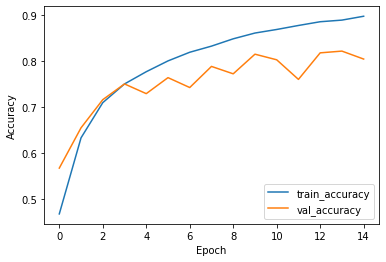

```python
plt.plot(history.history['accuracy'], label='train_accuracy')
plt.plot(history.history['val_accuracy'], label = 'val_accuracy')
plt.xlabel('Epoch')
plt.ylabel('Accuracy')
plt.legend(loc='lower right')
```

Het heeft dan wel geen effect gehad op de validation accuaracy met 15 epochs, maar wel is duidelijk te zien dat die nog niet klaar is met leren. Dus met meer epochs zou het een heel mooi effect kunnen opleveren. Er is nu dus nog geen spraken van overfitting!

Ik ga dit zelfde model niet trainen voor meer epochs, de tijd is gewoon te lang. Ik ga de epochs vergroten bij het volgende model, omdat uit de accuracy grafiek duidelijk te zien is dat die na 15 epochs nog niet klaar is met leren.

## Data augmentation

Data augmentation zou het model robuster moeten maken, met als gevolg een hogere accuracy score op de validation set.

Data augmentation gaat het overfitten tegen door meer train data te genereren. Het in en uit zoemen van de fotos het draaien en/of wazig maken. Dit zijn voorbeelden waarmee je extra train data kan genereren.

```python
model = Sequential()
```

```python
# Convolution Layer 1
model.add(Conv2D(32, (3, 3), activation='relu', input_shape=(32, 32, 3), padding='same', kernel_regularizer=regularizers.l2(0.0001)))
model.add(BatchNormalization())

# Convolution Layer 2
model.add(Conv2D(32, (3,3), padding='same', activation='relu', kernel_regularizer=regularizers.l2(0.0001)))
model.add(BatchNormalization())
model.add(MaxPooling2D(pool_size=(2,2)))
model.add(Dropout(0.2))

# Convolution Layer 3
model.add(Conv2D(64, (3,3), padding='same', activation='relu', kernel_regularizer=regularizers.l2(0.0001)))
model.add(BatchNormalization())

# Convolution Layer 4
model.add(Conv2D(64, (3,3), padding='same', activation='relu', kernel_regularizer=regularizers.l2(0.0001)))
model.add(BatchNormalization())
model.add(MaxPooling2D(pool_size=(2,2)))
model.add(Dropout(0.2))

# Convolution Layer 5
model.add(Conv2D(128, (3,3), padding='same', activation='relu', kernel_regularizer=regularizers.l2(0.0001)))
model.add(BatchNormalization())

# Convolution Layer 6
model.add(Conv2D(128, (3,3), padding='same', activation='relu', kernel_regularizer=regularizers.l2(0.0001)))
model.add(BatchNormalization())
model.add(MaxPooling2D(pool_size=(2,2)))
model.add(Dropout(0.2))
```

```python
model.add(Flatten()) # flatten toevoegen zodat we er een fully connected netwerk op kunnen aansluiten
```

```python
# Fully Connected Layer 7
model.add(Dense(128, activation='relu', kernel_regularizer=regularizers.l2(0.0001)))
model.add(BatchNormalization())

# Fully Connected Layer 8
model.add(Dense(64, activation='relu', kernel_regularizer=regularizers.l2(0.0001)))
model.add(BatchNormalization())

# Fully Connected Layer 9
model.add(Dense(32, activation='relu', kernel_regularizer=regularizers.l2(0.0001)))
model.add(BatchNormalization())

# Fully Connected Layer 10 (outputlayer)
model.add(Dense(10, activation='softmax'))
```

Het model heeft dus in totaal 10 layers. Het gevaar van te veel layers is dat je het model snel overfit. Ik ben van mening dat dit de maximale complexiteit van dit model moet zijn

```python
model.compile(loss='categorical_crossentropy', optimizer='adam', metrics=['accuracy'])
```

```python
#data augmentation
datagen = ImageDataGenerator(
    rotation_range=15,
    width_shift_range=0.1,
    height_shift_range=0.1,
    horizontal_flip=True,
    )
datagen.fit(X_train)
```

```python
startTime = time.time()
history_with_datagen = model.fit_generator(datagen.flow(X_train, y_train, batch_size=64), epochs=75, verbose=1, validation_data=(X_test, y_test))
print("Time: ", time.time() - startTime)
```

```
WARNING:tensorflow:From <ipython-input-18-97fdad312950>:2: Model.fit_generator (from tensorflow.python.keras.engine.training) is deprecated and will be removed in a future version.
Instructions for updating:
Please use Model.fit, which supports generators.
Time:  15615.318407535553
```

Het trainen heeft 15615 seconden geduurt.........

validation_split is niet mogelijk met fit_generator()

```python
print("Score:", max(history_with_datagen.history['val_accuracy']))
```

```
Score: 0.8683000206947327
```

Dit geeft weer een verbetering van 0.04 op de validation set. Of dit dus komt door het toevoegen van data augmentation of door de dropout en weight regularizer met meer epochs (want de vorige 2 modellen waren nog niet helemaal uitgetraint) weet ik niet. Dit zou je kunnen testen met met train tijden van 15615 seconden is dat niet te doen.

```python
print("High score with epoch: ", history_with_datagen.history['val_accuracy'].index(max(history_with_datagen.history['val_accuracy'])) + 1)
```

```
High score with epoch:  68
```

Met epoch 68 heeft het model een accuracy op de validation set van 0.87, super mooi resultaat!

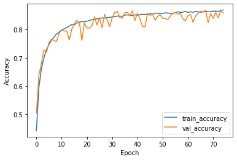

```python
plt.plot(history_with_datagen.history['accuracy'], label='train_accuracy')
plt.plot(history_with_datagen.history['val_accuracy'], label = 'val_accuracy')
plt.xlabel('Epoch')
plt.ylabel('Accuracy')
plt.legend(loc='lower right')
```

Hier is te zien dat er nog geen spraken is van overfitten. de train accuracy en de validation accuracy blijven beiden nog stijgen. Het model is naar mijn mening nog niet helemaal uitgetraint. Er is pas spraken van overfitting als de train accuracy blijft stijgen maar de validation accuracy niet meer.

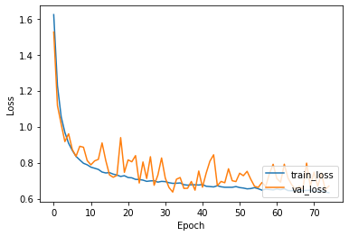

```python
plt.plot(history_with_datagen.history['loss'], label='train_loss')
plt.plot(history_with_datagen.history['val_loss'], label = 'val_loss')
plt.xlabel('Epoch')
plt.ylabel('Loss')
plt.legend(loc='lower right')
```

Ook is te zien dat er geen spraken is van overfitting door middel van de loss. De trainloss zou moeten blijven dalen en de validationloss het zelfde moeten blijven of zelfs stijgen. Dat is hier nog niet het geval bij de laatste epochs is zelfs af en toe de loss van de validation set lagen dan die van de train set.

```python
model.summary()
```

```
Model: "sequential_1"
_________________________________________________________________
Layer (type)                 Output Shape              Param #
=================================================================
conv2d_6 (Conv2D)            (None, 32, 32, 32)        896
_________________________________________________________________
batch_normalization_9 (Batch (None, 32, 32, 32)        128
_________________________________________________________________
conv2d_7 (Conv2D)            (None, 32, 32, 32)        9248
_________________________________________________________________
batch_normalization_10 (Batc (None, 32, 32, 32)        128
_________________________________________________________________
max_pooling2d_3 (MaxPooling2 (None, 16, 16, 32)        0
_________________________________________________________________
dropout_3 (Dropout)          (None, 16, 16, 32)        0
_________________________________________________________________
conv2d_8 (Conv2D)            (None, 16, 16, 64)        18496
_________________________________________________________________
batch_normalization_11 (Batc (None, 16, 16, 64)        256
_________________________________________________________________
conv2d_9 (Conv2D)            (None, 16, 16, 64)        36928
_________________________________________________________________
batch_normalization_12 (Batc (None, 16, 16, 64)        256
_________________________________________________________________
max_pooling2d_4 (MaxPooling2 (None, 8, 8, 64)          0
_________________________________________________________________
dropout_4 (Dropout)          (None, 8, 8, 64)          0
_________________________________________________________________
conv2d_10 (Conv2D)           (None, 8, 8, 128)         73856
_________________________________________________________________
batch_normalization_13 (Batc (None, 8, 8, 128)         512
_________________________________________________________________
conv2d_11 (Conv2D)           (None, 8, 8, 128)         147584
_________________________________________________________________
batch_normalization_14 (Batc (None, 8, 8, 128)         512
_________________________________________________________________
max_pooling2d_5 (MaxPooling2 (None, 4, 4, 128)         0
_________________________________________________________________
dropout_5 (Dropout)          (None, 4, 4, 128)         0
_________________________________________________________________
flatten_1 (Flatten)          (None, 2048)              0
_________________________________________________________________
dense_4 (Dense)              (None, 128)               262272
_________________________________________________________________
batch_normalization_15 (Batc (None, 128)               512
_________________________________________________________________
dense_5 (Dense)              (None, 64)                8256
_________________________________________________________________
batch_normalization_16 (Batc (None, 64)                256
_________________________________________________________________
dense_6 (Dense)              (None, 32)                2080
_________________________________________________________________
batch_normalization_17 (Batc (None, 32)                128
_________________________________________________________________
dense_7 (Dense)              (None, 10)                330
=================================================================
Total params: 562,634
Trainable params: 561,290
Non-trainable params: 1,344
_________________________________________________________________
```

# Evalueren

Het uiteindelijke model:

```python
model.summary()
```

```
Model: "sequential_1"
_________________________________________________________________
Layer (type)                 Output Shape              Param #
=================================================================
conv2d_6 (Conv2D)            (None, 32, 32, 32)        896
_________________________________________________________________
batch_normalization_9 (Batch (None, 32, 32, 32)        128
_________________________________________________________________
conv2d_7 (Conv2D)            (None, 32, 32, 32)        9248
_________________________________________________________________
batch_normalization_10 (Batc (None, 32, 32, 32)        128
_________________________________________________________________
max_pooling2d_3 (MaxPooling2 (None, 16, 16, 32)        0
_________________________________________________________________
dropout_3 (Dropout)          (None, 16, 16, 32)        0
_________________________________________________________________
conv2d_8 (Conv2D)            (None, 16, 16, 64)        18496
_________________________________________________________________
batch_normalization_11 (Batc (None, 16, 16, 64)        256
_________________________________________________________________
conv2d_9 (Conv2D)            (None, 16, 16, 64)        36928
_________________________________________________________________
batch_normalization_12 (Batc (None, 16, 16, 64)        256
_________________________________________________________________
max_pooling2d_4 (MaxPooling2 (None, 8, 8, 64)          0
_________________________________________________________________
dropout_4 (Dropout)          (None, 8, 8, 64)          0
_________________________________________________________________
conv2d_10 (Conv2D)           (None, 8, 8, 128)         73856
_________________________________________________________________
batch_normalization_13 (Batc (None, 8, 8, 128)         512
_________________________________________________________________
conv2d_11 (Conv2D)           (None, 8, 8, 128)         147584
_________________________________________________________________
batch_normalization_14 (Batc (None, 8, 8, 128)         512
_________________________________________________________________
max_pooling2d_5 (MaxPooling2 (None, 4, 4, 128)         0
_________________________________________________________________
dropout_5 (Dropout)          (None, 4, 4, 128)         0
_________________________________________________________________
flatten_1 (Flatten)          (None, 2048)              0
_________________________________________________________________
dense_4 (Dense)              (None, 128)               262272
_________________________________________________________________
batch_normalization_15 (Batc (None, 128)               512
_________________________________________________________________
dense_5 (Dense)              (None, 64)                8256
_________________________________________________________________
batch_normalization_16 (Batc (None, 64)                256
_________________________________________________________________
dense_6 (Dense)              (None, 32)                2080
_________________________________________________________________
batch_normalization_17 (Batc (None, 32)                128
_________________________________________________________________
dense_7 (Dense)              (None, 10)                330
=================================================================
Total params: 562,634
Trainable params: 561,290
Non-trainable params: 1,344
_________________________________________________________________
```

```python
loss, accuracy = model.evaluate(X_test, y_test)
print(f"Test loss: {loss:.4f}")
print(f"Test accuracy: {accuracy:.4f}")
```

```
Test loss: 0.6705
Test accuracy: 0.8574
```

Dit is op epoch 75

Op epoch 68 is er een resultaat van 0.8683000206947327. Dus **87 %** accuracy op de validation set!!!

Het model bleek nog niet overfit. Wel is het een erg complex model geworden. Het grote nadeel de tijd voor het trainen! 15615 seconden voor 75 epochs. Toch maar een keer een goede GPU aanschaffen **;)**